# ReproducibleProject2

Kumar Shaket

16/11/2020

## Data Analysis on NOAA Storm Database to identify Severe Weather Events

## Introduction

The basic goal of this assignment is to explore the NOAA Storm Database and answer some basic questions about severe weather events. You must use the database to answer the questions below and show the code for your entire analysis. Your analysis can consist of tables, figures, or other summaries. You may use any R package you want to support your analysis.

## Synopsis

This report will provide a better insight into Storms and severe weather events in United States and the Fatalities, Injuries and property damages left behind. Two questions to be answered:

1 - which types of events are most harmful to population health?

2 - which types of events have the greatest economic consequences?

#Data Processing

## Loading NOAA Data from CSV File

1. Download data from Coursera website
2. unzip file and convert it to csv
3. read csv file

```r
stormdata <- read.csv2("/Users/kumarshaket/Downloads/repdata-data-StormData.csv",sep = ",",header = TRUE)
```

```r
names(stormdata)
```

```
##  [1] "STATE__"    "BGN_DATE"   "BGN_TIME"   "TIME_ZONE"  "COUNTY"
##  [6] "COUNTYNAME" "STATE"      "EVTYPE"     "BGN_RANGE"  "BGN_AZI"
## [11] "BGN_LOCATI" "END_DATE"   "END_TIME"   "COUNTY_END" "COUNTYENDN"
## [16] "END_RANGE"  "END_AZI"    "END_LOCATI" "LENGTH"     "WIDTH"
## [21] "F"          "MAG"        "FATALITIES" "INJURIES"   "PROPDMG"
## [26] "PROPDMGEXP" "CROPDMG"    "CROPDMGEXP" "WFO"        "STATEOFFIC"
## [31] "ZONENAMES"  "LATITUDE"   "LONGITUDE"  "LATITUDE_E" "LONGITUDE_"
## [36] "REMARKS"    "REFNUM"
```

```r
head(stormdata,5)
```

```
##   STATE__           BGN_DATE BGN_TIME TIME_ZONE COUNTY COUNTYNAME STATE  EVTYPE
## 1    1.00  4/18/1950 0:00:00     0130       CST  97.00     MOBILE    AL TORNADO
## 2    1.00  4/18/1950 0:00:00     0145       CST   3.00    BALDWIN    AL TORNADO
## 3    1.00  2/20/1951 0:00:00     1600       CST  57.00    FAYETTE    AL TORNADO
## 4    1.00   6/8/1951 0:00:00     0900       CST  89.00    MADISON    AL TORNADO
## 5    1.00 11/15/1951 0:00:00     1500       CST  43.00    CULLMAN    AL TORNADO
##   BGN_RANGE BGN_AZI BGN_LOCATI END_DATE END_TIME COUNTY_END COUNTYENDN
## 1      0.00                                            0.00         NA
## 2      0.00                                            0.00         NA
## 3      0.00                                            0.00         NA
## 4      0.00                                            0.00         NA
## 5      0.00                                            0.00         NA
##   END_RANGE END_AZI END_LOCATI LENGTH  WIDTH F  MAG FATALITIES INJURIES PROPDMG
## 1      0.00                     14.00 100.00 3 0.00       0.00    15.00   25.00
## 2      0.00                      2.00 150.00 2 0.00       0.00     0.00    2.50
## 3      0.00                      0.10 123.00 2 0.00       0.00     2.00   25.00
## 4      0.00                      0.00 100.00 2 0.00       0.00     2.00    2.50
## 5      0.00                      0.00 150.00 2 0.00       0.00     2.00    2.50
##   PROPDMGEXP CROPDMG CROPDMGEXP WFO STATEOFFIC ZONENAMES LATITUDE LONGITUDE
## 1          K    0.00                                      3040.00   8812.00
## 2          K    0.00                                      3042.00   8755.00
## 3          K    0.00                                      3340.00   8742.00
## 4          K    0.00                                      3458.00   8626.00
## 5          K    0.00                                      3412.00   8642.00
##   LATITUDE_E LONGITUDE_ REMARKS REFNUM
## 1    3051.00    8806.00           1.00
## 2       0.00       0.00           2.00
## 3       0.00       0.00           3.00
## 4       0.00       0.00           4.00
## 5       0.00       0.00           5.00
```

## Processing data for analysis

## 1. Event Impact on Population Events

1.1 Converting fatalities from factor to numeric

```r
stormdata$FATALITIES <- as.numeric(stormdata$FATALITIES)
```

1.2 Calculating aggregate of fatalities for each environment

```r
FatalityperEvType <- aggregate(FATALITIES~EVTYPE,stormdata,sum)
dim(FatalityperEvType)
```

```
## [1] 985   2
```

1.3 Ordering Fatalities due to top 10 events

```r
Fatalities10events <-FatalityperEvType[order(-FatalityperEvType$FATALITIES),][1:10,]
Fatalities10events
```

```
##                 EVTYPE FATALITIES
## 244               HAIL     288719
## 856          TSTM WIND     221433
## 760  THUNDERSTORM WIND      82943
## 834            TORNADO      79987
## 153        FLASH FLOOD      58315
## 170              FLOOD      27282
## 359          HIGH WIND      21121
## 786 THUNDERSTORM WINDS      21021
## 464          LIGHTNING      17272
## 310         HEAVY SNOW      16196
```

1.4 Plot for Fatalities due to top 10 events

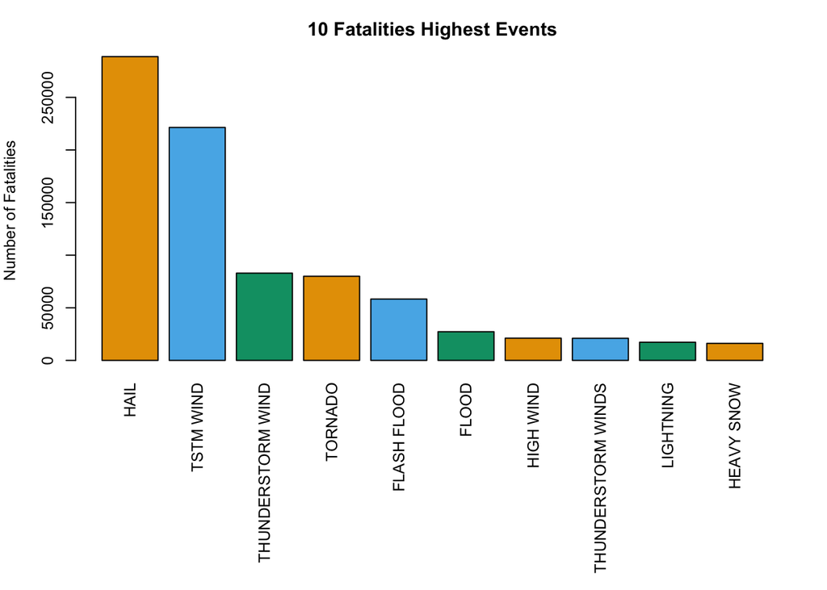

```r
par(mfrow = c(1,1), mar = c(12, 4, 3, 2), mgp = c(3, 1, 0), cex = 0.8)
barplot(Fatalities10events$FATALITIES,names.arg = Fatalities10events$EVTYPE,las=3,col=c("#E69F00", "#56B4E9", "#009E73"),ylab = "Number of Fatalities", main = "10 Fatalities Highest Events")
```

## 2. Event impacting Economies

2.1 Converting PropertyExpense from factor to numeric

```r
stormdata$PROPDMGEXP=as.numeric(stormdata$PROPDMGEXP)
```

```r
PROPDMGEvtype <- aggregate(PROPDMGEXP ~ EVTYPE,stormdata,sum)
dim(PROPDMGEvtype)
```

```
## [1] 985   2
```

2.3 Ordering Property Expense due to top 10 event

```r
PROPDMG10Events <- PROPDMGEvtype[order(-PROPDMGEvtype$PROPDMGEXP),][1:10,]
PROPDMG10Events
```

```
##                 EVTYPE PROPDMGEXP
## 244               HAIL    1762050
## 760  THUNDERSTORM WIND    1394171
## 856          TSTM WIND    1226522
## 834            TORNADO     898934
## 153        FLASH FLOOD     584451
## 170              FLOOD     306671
## 359          HIGH WIND     246783
## 786 THUNDERSTORM WINDS     209344
## 464          LIGHTNING     191710
## 972       WINTER STORM     131904
```

2.4 Plot for Property Damage Expense due to top 10 events

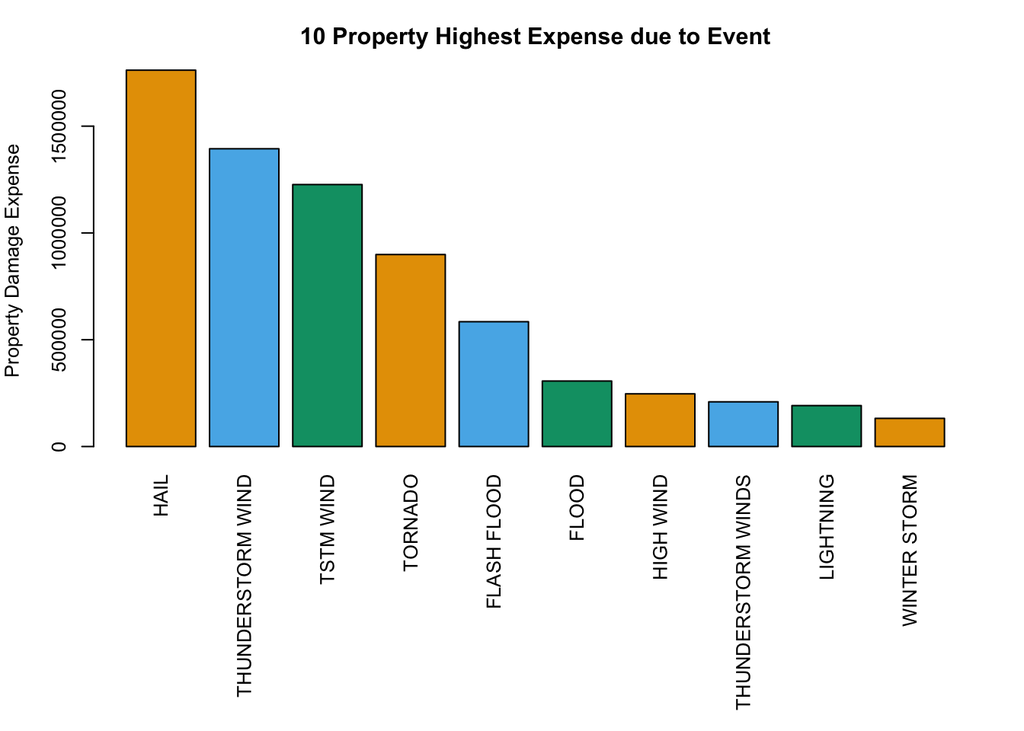

```r
par(mfrow = c(1,1), mar = c(12, 4, 3, 2), mgp = c(3, 1, 0), cex = 0.8)
barplot(PROPDMG10Events$PROPDMGEXP,names.arg = PROPDMG10Events$EVTYPE,las=3,col=c("#E69F00", "#56B4E9", "#009E73"),ylab = "Property Damage Expense", main = "10 Property Highest Expense due to Event")
```

## 3. Crop Damage

3.1 Converting CropDamage from factor to numeric

```r
stormdata$CROPDMGEXP=as.numeric(stormdata$CROPDMGEXP)
```

```r
CROPDMGEvtype <- aggregate(CROPDMGEXP ~ EVTYPE,stormdata,sum)
dim(CROPDMGEvtype)
```

```
## [1] 985   2
```

3.3 Ordering Crop Damage due to top 10 event

```r
CROPDMG10Events <- CROPDMGEvtype[order(-CROPDMGEvtype$CROPDMGEXP),][1:10,]
PROPDMG10Events
```

[output not shown]

2.4 Plot for Crop Dmaage Expense due to top 10 events

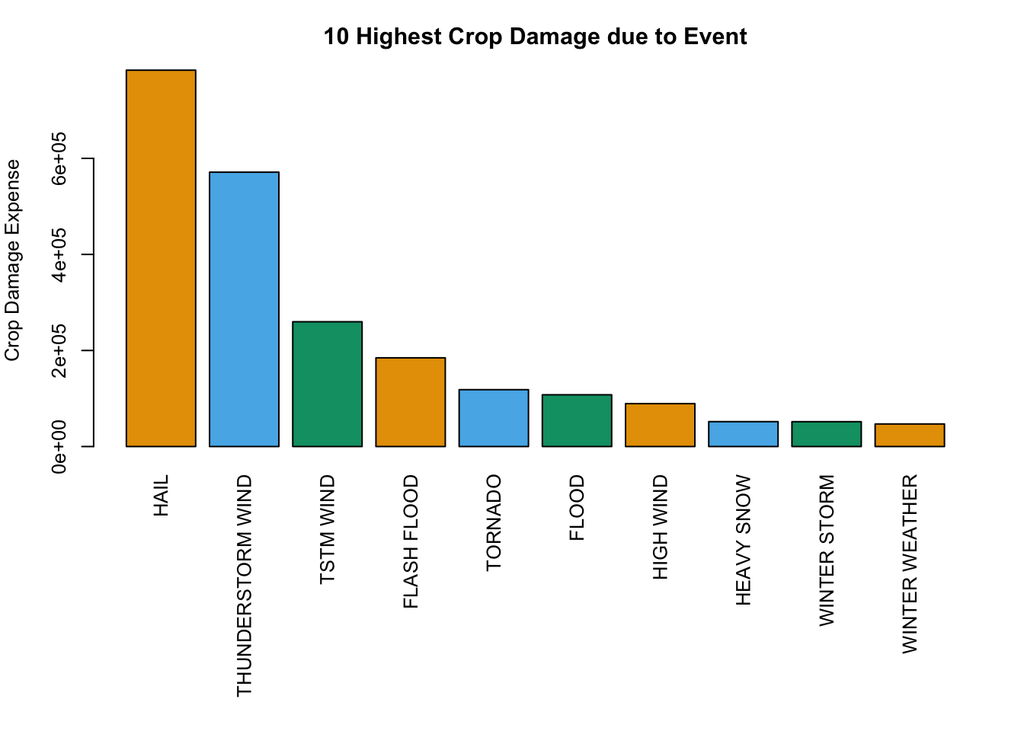

```r
par(mfrow = c(1,1), mar = c(12, 4, 3, 2), mgp = c(3, 1, 0), cex = 0.8)
barplot(CROPDMG10Events$CROPDMGEXP,names.arg = CROPDMG10Events$EVTYPE,las=3,col=c("#E69F00", "#56B4E9", "#009E73"),ylab = "Crop Damage Expense", main = "10 Highest Crop Damage due to Event")
```

##Results 1.1 : Across the United States, which types of events (as indicated in the EVTYPE(EVTYPE variable) are most harmful with respect to population health? 1.2 : Across the United States, which types of events have the greatest economic consequences?